# Problem Set 8

Due date: 20 November

Please upload your completed assignment to the ELMs course site (under the assignments menu). Remember to include an annotated script file for all work with R and show your math for all other problems (if applicable, or necessary). Please also upload your completed assignment to the Github repository that you have shared with us. *We should be able to run your script with no errors.*

**Total points: 30**

## Question 1

*Points: 5*

**Note**

5/5

For the following regression equation, $\hat{Y} = 8.5 + 6x + \epsilon$, the standard error for $\beta_0$ is 2.5, the standard error for $\beta_1$ is 3.5, and the sample size is 2000. Find the t-statistic, 95% confidence interval, and p-value (using a two-tailed test) for $\beta_1$.

Is $\beta_1$ statistically significant at the 0.05-level with a two-tailed test? Why or why not?

**Answer**: First, we have to determine the t-statistic for $\beta_1$.
$$t = \frac{\hat{\beta}_1}{SE(\hat{\beta}_1)}$$

```r
beta_1 <- 6
se_beta_1 <- 3.5
tstat_beta_1 <- beta_1 / se_beta_1

tstat_beta_1
```

```
[1] 1.714286
```

We can derive also 95% confidence interval after finding the critical value, $t_{critical}$.

```r
df <- 2000 - 1 - 1
t_critical <- qt(0.025, df = df, lower.tail = F)

upper_ci <- beta_1 + t_critical * se_beta_1

lower_ci <- beta_1 - t_critical * se_beta_1

upper_ci
```

```
[1] 12.86403
```

```r
lower_ci
```

```
[1] -0.8640321
```

```r
p_beta_1 <- 2 * pt(tstat_beta_1, df = df, lower.tail = F)
```

The t-statistic of 1.7142857 produces a p of 0.0866314. This means that $\beta_1$ is not significant at the 0.05 level since $p > 0.05$.

## Question 2

*Points: 5*

**Note**

1/5

Suppose you estimate an OLS regression and retrieve a $R^2$ value of 0.45. If the Total Sum of Squares (TSS) from that regression equals 4,700, what is the value for the Residual Sum of Squares (RSS)?

**Answer**: We can find the RSS by first solving for the ESS through the $R^2$ formula:
$$R^2 = \frac{ESS}{TSS}$$

```r
r_squared <- 0.45
TSS <- 4700
ESS <- r_squared * TSS
ESS
```

```
[1] 2115
```

```r
RSS <- ESS + TSS
RSS
```

```
[1] 6815
```

**Note**

$$R^2 = 1 - \frac{RSS}{TSS}$$

Therefore:

$$0.45 = 1 - \frac{RSS}{4700}$$

Therefore:

$$RSS = 2585$$

## Question 3

*Points: 5*

**Note**

5/5

Suppose you estimate a bivariate regression with a sample size of 102 and obtain a regression coefficient ($\beta_1$) of 5.0. What is the largest standard error that $\beta_1$ could have and still be statistically significant (i.e., reject the null hypothesis of no relationship) at the 0.05 level with a one-tailed test?

**Answer**: First, we have to determine the critical value according to the 0.05 significance level. We can find this using the degrees of freedom.

```r
df_03 <- 102 - 1 - 1
t_critical_03 <- qt(0.05, df = df_03, lower.tail = F)
t_critical_03
```

```
[1] 1.660234
```

We can reconfigure the t-statistic forula to solve for the critical standard error using this critical value.
$$SE_{critical} = \frac{\beta_1}{t_{critical}}$$

```r
beta_1 <- 5
se_critical <- beta_1 / t_critical_03
se_critical
```

```
[1] 3.011623
```

The largest standard error that $\beta_1$ could have and still be statistically significant (i.e., reject the null hypothesis of no relationship) at the 0.05 level with a one-tailed test is 3.0116231.

## Question 4

*Points: 5*

**Note**

4/5

```r
gapminder_df <- wbstats::wb_data(c("NY.GDP.PCAP.CD", "SP.DYN.LE00.IN"),
                                 start_date = 2019, end_date = 2019) |>
  dplyr::rename(gdp_per_cap = "NY.GDP.PCAP.CD", life_exp = "SP.DYN.LE00.IN")
```

Using the `gapminder_df` data set read in above, produce a scatterplot of the variables `gdp_per_cap` and `life_exp` (with `life_exp` as the dependent variable on the y-axis). Fit a regression line to the scatterplot. Describe the relationship illustrated. Note any suspected outliers, if any (a visual inspection will suffice for this question).

**Note**

The variable `gdp_per_cap` measures each country’s GDP per capita (representing their individual wealth), and `life_exp` indicates the number of years individuals within that country born that year are expected to live (representing their health).

**Answer**:

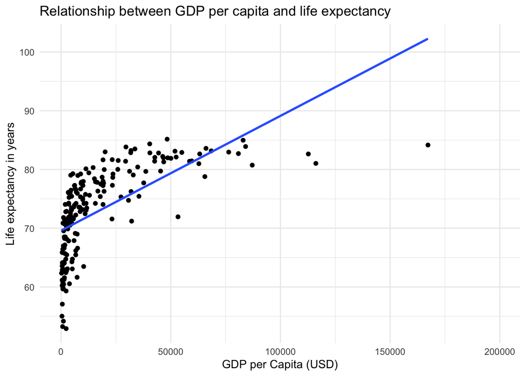

```r
library(tidyverse)
library(broom)
library(modelsummary)
library(ggdist)

ggplot(gapminder_df, aes(x = gdp_per_cap, y = life_exp)) +
  geom_point() +
  geom_smooth(method = "lm", se = F) +
  theme_minimal() +
  labs(title = "Relationship between GDP per capita and life expectancy",
       x = "GDP per Capita (USD)",
       y = "Life expectancy in years")
```

Generally, GDP per capita has been positively associated with increasing life expectancy. Countries with higher GDP per capita tend to have longer life expectancies. There are a few outlier cases which have abnormally high GDP per capita values with life expectancies hovering slightly above the 80s, similar to many countries at lower GDP per capita ranges.

**Note**

Need to identify that the relationship is not linear.

## Question 5

*Points: 10*

**Note**

9/10

**Note**

Should only fit linear models to estimate linear relationships. Better to use the logged GDP per capita.

Estimate a bivariate regression with `life_exp` as the dependent variable and `gdp_per_cap` as the independent variable and report the results in a professionally formatted table. In as much detail as possible, describe (and interpret) the regression results. **This relationship is not linear.**

**Answer**:

```r
regression_05 <- lm(life_exp ~ log(gdp_per_cap), data = gapminder_df)
summary(regression_05)
```

```
Call:
lm(formula = life_exp ~ log(gdp_per_cap), data = gapminder_df)

Residuals:
     Min       1Q   Median       3Q      Max
-15.2913  -2.0714   0.5269   2.6508   8.0501

Coefficients:
                 Estimate Std. Error t value Pr(>|t|)
(Intercept)       34.5047     1.7546   19.66   <2e-16 ***
log(gdp_per_cap)   4.3450     0.1953   22.24   <2e-16 ***
---
Signif. codes:  0 '***' 0.001 '**' 0.01 '*' 0.05 '.' 0.1 ' ' 1

Residual standard error: 4.03 on 200 degrees of freedom
  (15 observations deleted due to missingness)
Multiple R-squared:  0.7121,    Adjusted R-squared:  0.7107
F-statistic: 494.8 on 1 and 200 DF,  p-value: < 2.2e-16
```

```r
modelsummary(regression_05,
             coef_rename = c("log(gdp_per_cap)" = "Logged GDP per capita (USD)"),
             statistic = c("std.error", "p.value"))
```

|  | (1) |
| --- | --- |
| (Intercept) | 34.505 |
|  | (1.755) |
|  | (<0.001) |
| Logged GDP per capita (USD) | 4.345 |
|  | (0.195) |
|  | (<0.001) |
| Num.Obs. | 202 |
| R2 | 0.712 |
| R2 Adj. | 0.711 |
| AIC | 1140.4 |
| BIC | 1150.3 |
| Log.Lik. | -567.183 |
| RMSE | 4.01 |